# Leaflet Mapping using Spatial Autocorrelation Results

Ashley Baker – Advanced Spatial Quantitative Analysis

February 6th, 2019 |

# Packages Used

```r
suppressPackageStartupMessages(require(leaflet))
suppressPackageStartupMessages(require(sp))
suppressPackageStartupMessages(require(tidycensus))
suppressPackageStartupMessages(require(rgdal))
suppressPackageStartupMessages(require(lwgeom))
suppressPackageStartupMessages(require(spdep))
```

# Local Getis-Ord G

We will define the Detroit Metro Area as the following counties: Oakland, Macomb, and Wayne.

```r
#download ACS data

tract <- tidycensus::get_acs(
  geography = 'tract',
  state = 'MI',
  county = c('Oakland', 'Macomb', 'Wayne'), # Detroit metro
  variables = c('B22010_001E', 'B22010_002E' ), # total households, food assistance
  geometry = TRUE,
  output = 'wide'
)
tractmhi<-tidycensus::get_acs(geography= 'tract', state='MI', county=c ('Oakland', 'Macomb', 'Wayne'), variables= 'B19049_001E', geometry=TRUE, output='wide') #download median household income data for explanatory comparison later

#Process data as necessary for tests and mapping

# redefine variable names
tract$household <- tract$B22010_001E
tract$food<-tract$B22010_002E
tractmhi$mhi<-tractmhi$B19049_001E

#fill mhi, which contains NA values, with zeros
tractmhi$mhi<-ifelse(is.na(tractmhi$mhi), 0, tractmhi$mhi) # if it is NA, fill it with a zero, otherwise leave it as-is

lesszero<-as.vector(sf::st_area(tract))>0
#there is one "FALSE" in table(lesszero), indicating a zero area polygon

lesszero2<-as.vector(sf::st_area(tractmhi))>0

tract<-as(tract[lesszero,], "Spatial") #this will return all polygons in the tract data that have a TRUE assignment in 'lesszero', as well as converting tract from sf to sp
tractmhi<-as(tractmhi[lesszero2,], "Spatial")

#confirm data is sp using class(tract)
```

After making sure that the data is represented properly in a spatial polygon format, we can continue by further processing the data to create proportions of households receiving food assistance for each tract within the Detroit Metro area.

```r
tract$prop_assist<-ifelse(tract$food==0, 0, tract$food/tract$household) #to avoid issues arising from dividing a zero value (which will return NA)
```

Now we can create the weights matrix necessary for running the desired spatial autocorrelation tests. In order to determine the most appropriate approach to creating the weights matrix, the study area must be examined to determine connectivity as well as relative sizes and locations of the tracts. It appears as though all polygons are contiguous and suited for a Queen’s contiguity weights matrix.

```r
tract_nb<-spdep::poly2nb(pl= tract, queen=TRUE)  #polygon to neighbor using Queen's contiguity

tract_w<-spdep::nb2listw(neighbours=tract_nb, style= "W", zero.policy=TRUE) #don't forget to spell 'neighbors' with a u

tract_localG<- as.vector(spdep::localG(x=tract$prop_assist, listw=tract_w,    zero.policy=TRUE)) #run Getis Ord local Gi* test
```

Although the results of the localG test provide a numeric vector, interpretation in this format is limited. To visualize the results of the Local Getis-Ord Gi* test, it is necessary to identify significant z-scores, indicating areas of clustering. This is done by creating a color scheme to be mapped.

```r
col_G_z<-NA
col_G_z<-ifelse(tract_localG > -1.96 & tract_localG< 1.96, 'snow', col_G_z)
col_G_z<- ifelse(tract_localG >= 1.96 & tract_localG< 2.58, 'pink', col_G_z)
col_G_z<- ifelse(tract_localG >= 2.58, 'maroon', col_G_z)
col_G_z<- ifelse(tract_localG<= -1.96 & tract_localG > -2.58, "lightblue", col_G_z)
col_G_z<- ifelse(tract_localG <= -2.58, 'navy', col_G_z)
```

# Interactive Map

The next step is to build the actual leaflet map itself, using data processed earlier.

[interactive chart not shown]

Ho: The proportion of households receiving food assistance is randomly distributed

Ha: The proportion of households receiving food assistance is not randomly distributed

The leaflet map created to exhibit the Local Getis-Ord Gi* statistic yields some interesting results. This test, which identifies areas where there is clustering of high and low values, is capable of exhibiting the significance of this clustering, or each tract’s values compared to it’s neighbors, as local z-scores are provided. The visualization of these results allows us to reject Ho, as there are obvious areas of clustering throughout the city. For example, we see that there is an area of highly significant high-value clustering near central-East side of the city(z>=2.58), with tracts of significant clustering (1.96<=z<2.58) appearing around the periphery. Additionally, there are large areas of clustering noticeable in the northwestern and central areas of Detroit metro where food assistance proportions are both significantly low (-1.96<=z>-2.58) and highly low (z<=-2.58). Due to both the pattern of clustering, with high values clustering located within smaller census tracts (indicating higher population density), and location, with high clustering near the water (industry), it might be assumed that the areas with high food assistance are in the downtown/inner urban region of Detroit. The obvious clustering also suggests a possible relationship with household income, and so it would be advantageous to view maps of both to see if spatial trends might be visually obvious.

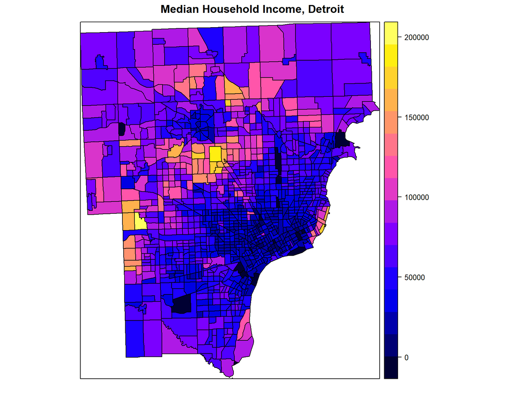

```r
spplot(tractmhi['mhi'], main="Median Household Income, Detroit") #to visually compare mhi to the local G results
```

The patterns of median household income appear to correspond quite readily with the clusters of households receiving food assistance. MHI is low in the area with the highly significant high proportion of assistance households, while the lowest low-value clusters are scattered throughout the areas with the city’s wealthiest census tracts. Although there are other landscape characteristics (related to property desirability, potential hazard, etc) and sociodemographic factors (education, etc) that would surely show some correlation with household food assistance, household income seems like a valid place to begin identifying trends. —-